# RIS in Ternay Alloys

## 1. Fractional concentration

\begin{equation*} X_{Fe}=\Omega C_{Fe} \end{equation*} \begin{equation*} X_{Cr}=\Omega C_{Cr} \end{equation*} \begin{equation*} X_{Ni}=\Omega C_{Ni} \end{equation*} Where  
Average atomic volume \begin{equation*} \Omega = \frac{1}{N} \end{equation*} Atomic density \begin{equation*} N = 9.1\times 10^{28} \#/m^{3} \end{equation*}

## 2. Continuity equations

\begin{equation*} \frac{dX_{Fe}}{dt}=-\Omega \times \triangledown J_{Fe} \end{equation*} \begin{equation*} \frac{dX_{Cr}}{dt}=-\Omega \times \triangledown J_{Cr} \end{equation*} \begin{equation*} \frac{dX_{Ni}}{dt}=-\Omega \times \triangledown J_{Ni} \end{equation*} \begin{equation*} \frac{dX_{v}}{dt}=-\Omega \times \triangledown J_{v}+G_{v}-R\times X_{v}\times X_{i} \end{equation*} \begin{equation*} \frac{dX_{i}}{dt}=-\Omega \times \triangledown J_{i}+G_{i}-R\times X_{v}\times X_{i} \end{equation*}

## 3. Flux eqaution for atoms and defects

\begin{equation*} \Omega\times J_{Fe}=-\alpha D_{Fe}(1-X_{Fe})\triangledown X_{Fe}+[\alpha D_{Cr}\triangledown X_{Cr}+\alpha D_{Ni}\triangledown X_{Ni}+(d_{Fe}^{v}-D_{v})\triangledown X_{v}+(D_{i}-d_{Fe}^{i})\triangledown X_{i}]X_{Fe} \end{equation*} \begin{equation*} \Omega\times J_{Cr}=-\alpha D_{Cr}(1-X_{Cr})\triangledown X_{Cr}+[\alpha D_{Fe}\triangledown X_{Fe}+\alpha D_{Ni}\triangledown X_{Ni}+(d_{Cr}^{v}-D_{v})\triangledown X_{v}+(D_{i}-d_{Cr}^{i})\triangledown X_{i}]X_{Cr} \end{equation*} \begin{equation*} \Omega\times J_{Ni}=-\alpha D_{Ni}(1-X_{Ni})\triangledown X_{Ni}+[\alpha D_{Cr}\triangledown X_{Cr}+\alpha D_{Fe}\triangledown X_{Fe}+(d_{Ni}^{v}-D_{v})\triangledown X_{v}+(D_{i}-d_{Ni}^{i})\triangledown X_{i}]X_{Ni} \end{equation*} \begin{equation*} \Omega\times J_{v}=-D_{v}\triangledown X_{v}+\alpha X_{v}(d_{Fe}^{v}\triangledown X_{Fe}+d_{Cr}^{v}\triangledown X_{Cr}+d_{Ni}^{v}\triangledown X_{Ni}) \end{equation*} \begin{equation*} \Omega\times J_{i}=-D_{i}\triangledown X_{i}-\alpha X_{i}(d_{Fe}^{i}\triangledown X_{Fe}+d_{Cr}^{i}\triangledown X_{Cr}+d_{Ni}^{i}\triangledown X_{Ni}) \end{equation*}

## 4. Diffusion coefficients

\begin{equation*} D_{Fe}=d_{Fe}^{v}X_{v}+d_{Fe}^{i}X_{i} \end{equation*} \begin{equation*} D_{Cr}=d_{Cr}^{v}X_{v}+d_{Cr}^{i}X_{i} \end{equation*} \begin{equation*} D_{Ni}=d_{Ni}^{v}X_{v}+d_{Ni}^{i}X_{i} \end{equation*} \begin{equation*} D_{v}=d_{Fe}^{v}X_{Fe}+d_{Cr}^{v}X_{Cr}+d_{Ni}^{v}X_{Ni} \end{equation*} \begin{equation*} D_{i}=d_{Fe}^{i}X_{Fe}+d_{Cr}^{i}X_{Cr}+d_{Ni}^{i}X_{Ni} \end{equation*}

## 5. Diffusivities

### Vacancies

\begin{equation*} \lambda_{a}^{v}=\lambda \end{equation*} \begin{equation*} d_{Fe}^{v}=\nu_{Fe}^{v}(\lambda_{a}^{v})^{2} \end{equation*} \begin{equation*} d_{Cr}^{v}=\nu_{Cr}^{v}(\lambda_{a}^{v})^{2} \end{equation*} \begin{equation*} d_{Ni}^{v}=\nu_{Ni}^{v}(\lambda_{a}^{v})^{2} \end{equation*}

### Interstitial

\begin{equation*} \lambda_{a}^{i}=\sqrt{\frac{2}{3}}\lambda \end{equation*} \begin{equation*} d_{Fe}^{i}=\nu_{Fe}^{i}(\lambda_{a}^{i})^{2} \end{equation*} \begin{equation*} d_{Cr}^{i}=\nu_{Cr}^{i}(\lambda_{a}^{i})^{2} \end{equation*} \begin{equation*} d_{Ni}^{i}=\nu_{Ni}^{i}(\lambda_{a}^{i})^{2} \end{equation*}

## 6. Jump frequency

\begin{equation*} \nu_{Fe}^{v}=\nu_{Fe}^{v,0}e^{-\frac{E_{Fe}^{v,m}}{k_{b}T}} \end{equation*} \begin{equation*} \nu_{Cr}^{v}=\nu_{Cr}^{v,0}e^{-\frac{E_{Cr}^{v,m}}{k_{b}T}} \end{equation*} \begin{equation*} \nu_{Ni}^{v}=\nu_{Ni}^{v,0}e^{-\frac{E_{Ni}^{v,m}}{k_{b}T}} \end{equation*} \begin{equation*} \nu_{Fe}^{i}=f^{i}\nu^{i,0}e^{-\frac{E^{i,m}}{k_{b}T}} \end{equation*} \begin{equation*} \nu_{Cr}^{i}=f^{i}\nu^{i,0}e^{-\frac{E^{i,m}}{k_{b}T}} \end{equation*} \begin{equation*} \nu_{Ni}^{i}=f^{i}\nu^{i,0}e^{-\frac{E^{i,m}}{k_{b}T}} \end{equation*}

## 7. Migration energy

### Pair interaction energy

#### Like atoms

\begin{equation*} E_{CrCr}=\frac{2E_{coh}^{Cr}}{Z} \end{equation*} \begin{equation*} E_{FeFe}=\frac{2E_{coh}^{Fe}}{Z} \end{equation*} \begin{equation*} E_{NiNi}=\frac{2E_{coh}^{Ni}}{Z} \end{equation*}

#### Unlike atoms

\begin{equation*} E_{NiCr}=\frac{E_{NiNi}+E_{CrCr}}{2}- E_{NiCr}^{ord}\end{equation*} \begin{equation*} E_{FeCr}=\frac{E_{FeFe}+E_{CrCr}}{2}- E_{FeCr}^{ord}\end{equation*} \begin{equation*} E_{FeNi}=\frac{E_{FeFe}+E_{NiNi}}{2}- E_{FeNi}^{ord}\end{equation*}

#### Atoms and vacancies

\begin{equation*} E_{Cr-v}=\frac{E_{coh}^{Cr}+E_{f}^{Cr-v}}{Z}\end{equation*} \begin{equation*} E_{Ni-v}=\frac{E_{coh}^{Ni}+E_{f}^{Ni-v}}{Z}\end{equation*} \begin{equation*} E_{Fe-v}=\frac{E_{coh}^{Fe}+E_{f}^{Fe-v}}{Z}\end{equation*}

### Saddle point energy

\begin{equation*} ES_{pure}^{Cr}=E_{m}^{Cr-v}+Z(E_{CrCr}+E_{Cr-v})\end{equation*}

### Vacancy migration energy

\begin{equation*} E_{Fe}^{v,m}=C_{Fe}(-\frac{3}{2}E_{Fe}^{coh}+\frac{1}{2}E_{Fe,pure}^{v,m}-\frac{1}{2}E_{Fe}^{v,f})+C_{Cr}(-E_{Fe}^{coh}-\frac{1}{2}E_{Cr}^{coh}+\frac{1}{2}E_{Cr,pure}^{v,m}-\frac{1}{2}E_{Cr}^{v,f}-ZE_{FeCr}^{ord})+C_{Ni}(-E_{Fe}^{coh}-\frac{1}{2}E_{Ni}^{coh}+\frac{1}{2}E_{Ni,pure}^{v,m}-\frac{1}{2}E_{Ni}^{v,f}-ZE_{NiFe}^{ord})+C_{v}(-E_{Fe}^{coh}-E_{Fe}^{v,f})+(\frac{3}{2}E_{Fe}^{coh}+\frac{1}{2}E_{Fe,pure}^{v,m}+\frac{1}{2}E_{Fe}^{v,f}) \end{equation*} \begin{equation*} E_{Cr}^{v,m}=C_{Cr}(-\frac{3}{2}E_{Cr}^{coh}+\frac{1}{2}E_{Cr,pure}^{v,m}-\frac{1}{2}E_{Cr}^{v,f})+C_{Fe}(-E_{Cr}^{coh}-\frac{1}{2}E_{Fe}^{coh}+\frac{1}{2}E_{Fe,pure}^{v,m}-\frac{1}{2}E_{Fe}^{v,f}-ZE_{FeCr}^{ord})+C_{Ni}(-E_{Cr}^{coh}-\frac{1}{2}E_{Ni}^{coh}+\frac{1}{2}E_{Ni,pure}^{v,m}-\frac{1}{2}E_{Ni}^{v,f}-ZE_{NiCr}^{ord})+C_{v}(-E_{Cr}^{coh}-E_{Cr}^{v,f})+(\frac{3}{2}E_{Cr}^{coh}+\frac{1}{2}E_{Cr,pure}^{v,m}+\frac{1}{2}E_{Cr}^{v,f}) \end{equation*} \begin{equation*} E_{Ni}^{v,m}=C_{Ni}(-\frac{3}{2}E_{Ni}^{coh}+\frac{1}{2}E_{Ni,pure}^{v,m}-\frac{1}{2}E_{Ni}^{v,f})+C_{Fe}(-E_{Ni}^{coh}-\frac{1}{2}E_{Fe}^{coh}+\frac{1}{2}E_{Fe,pure}^{v,m}-\frac{1}{2}E_{Fe}^{v,f}-ZE_{FeNi}^{ord})+C_{Cr}(-E_{Ni}^{coh}-\frac{1}{2}E_{Cr}^{coh}+\frac{1}{2}E_{Cr,pure}^{v,m}-\frac{1}{2}E_{Cr}^{v,f}-ZE_{NiCr}^{ord})+C_{v}(-E_{Ni}^{coh}-E_{Ni}^{v,f})+(\frac{3}{2}E_{Ni}^{coh}+\frac{1}{2}E_{Ni,pure}^{v,m}+\frac{1}{2}E_{Ni}^{v,f}) \end{equation*}

### Interstitial migration energy

\begin{equation*} E^{i,m}=0.9eV \end{equation*}

## 7. Defect production rate

\begin{equation*} G_{v}=\eta\phi+\rho D_{v}(X_{v}^{th}-X_{v})\end{equation*} \begin{equation*} X_{v}^{th}=e^{\frac{S^{v,f}}{k_{b}}}e^{-\frac{E^{v,f}}{k_{b}T}} \end{equation*} \begin{equation*} \end{equation*} \begin{equation*} G_{i}=\eta\phi+\rho D_{i}(X_{i}^{th}-X_{i}) \end{equation*} \begin{equation*} X_{v}^{th}=small \end{equation*} \begin{equation*} R=[(\nu_{Fe}^{v}+\nu_{Fe}^{i})X_{Fe}+(\nu_{Cr}^{v}+\nu_{Cr}^{i})X_{Cr}+(\nu_{Ni}^{v}+\nu_{Ni}^{i})X_{Ni}]Z \end{equation*}

A system of PDEs \begin{equation*} \frac{\partial u_{1}}{\partial t}=0.024\frac{\partial^{2}u_{1}}{\partial x^{2}}-F(u_{1}-u_{2}) \end{equation*} \begin{equation*} \end{equation*} \begin{equation*} \frac{\partial u_{2}}{\partial t}=0.017\frac{\partial^{2}u_{2}}{\partial x^{2}}+F(u_{1}-u_{2}) \end{equation*} \begin{equation*} \end{equation*} \begin{equation*} F(x)=e^{5.73x}-e^{-11.46x} \end{equation*} Initial conditions \begin{equation*} u_{1}(x,0)=1,u_{2}(x,0)=0 \end{equation*} Boundary conditions \begin{equation*} u_{1}(0,t)=0, \frac{\partial u_{1}(0,t)}{\partial x}=0, u_{2}(1,t)=1,\frac{\partial u_{2}(1,t)}{\partial x}=0 \end{equation*}

## Algorithms

1) Input data  
2) Set up all variables  
3) Claculate energies, jump frequencies, diffusivities, diffusion coefficients  
4) Discretize fractional concentrations  
5) Apply PDE solver to continuity equations  
6) Output fractional concentration tensor (L×T×5) </P>

# Solving Partial Differential Equations

A method of lines for partial differential equations (PDEs) where one reduces a PDE to a system of ODE and then applies standard methods. \begin{equation*} \frac{\partial u(x, t)}{\partial t}=\beta \frac{\partial^2u(x, t)} {\partial x^{2}}+f(x, t),x\in[0, L],t\in[0, T] \end{equation*} \begin{equation*} u(0, t)=s(t),t\in[0,T] \end{equation*} \begin{equation*} \frac{\partial}{\partial x}u(L,t)=0,t\in[0, T] \end{equation*} \begin{equation*} u(x,0)=I(x),x\in[0,L] \end{equation*} Discretizing the 2nd-order derivative in space with a finite difference on a mesh \begin{equation*} x_{i}=i\Delta x, i=1,...,N-1 \end{equation*} then ODE: \begin{equation*} \frac{\partial u_{i}(t)}{\partial t}=\beta \frac{u_{i+1}(t)-2u_{i}(t)+u_{i-1}(t)}{\Delta x^{2}}+f_{i}(t), i=1,...,N-1 \end{equation*} The boundary condition on x=0, u(0,t)=s(t), gives rise to the ODE \begin{equation*} u_{0}^{'}=s^{'}(t),u_{0}(0)=s(0) \end{equation*} At the other end, x=L, we use a centered difference approximation The boundary condition on x=0, u(0,t)=s(t), gives rise to the ODE \begin{equation*} \frac{u_{N+1}(t)-u_{N-1}(t)}{2\Delta x}=0 \end{equation*} and combine it with the scheme for i=N to obtain the modified boundary ODE \begin{equation*} \frac{\partial u_{N}(t)}{\partial t}=\beta \frac{2u_{N-1}(t)-2u_{N}(t)}{\partial x^{2}}+f_{N}(t) \end{equation*} To summarize, the ODE system reads \begin{equation*} \frac{du_{0}}{dt}=s^{'}(t) \end{equation*} \begin{equation*} \frac{du_{i}}{dt}=\frac{\beta}{\Delta x^{2}}(u_{i+1}(t)-2u_{i}(t)+2u_{i-1}(t))+f_{i}(t),i=1,...,N-1 \end{equation*} \begin{equation*} \frac{du_{N}}{dt}=\frac{2\beta}{\Delta x^{2}}(u_{N-1}(t)-u_{N}(t))+f_{i}(t) \end{equation*} The initial conditions are \begin{equation*} u_{0}(0)=s(0) \end{equation*} \begin{equation*} u_{i}(0)=I(x_{i}),i=1,...,N \end{equation*}

# Points

6/03/2020  
Compléter des unités pour chaque paramètre  
Rlier une variable et son unité  
Rendre des variables en ordre et lisible  
Evaluer des algorithms en fonction de la complexité en temps  
13/03/2020  
Distinguer des paramètres physiques et ceux-ci numériques  
Faire une table de tous les parameters avec certaines sets

```python
"""
Python version:
This code need Python 2.7 compile environment beacause of a package odespy.

Install odespy:
This operation as followed is uniquely supported in Google Colab. If you use
another platform such as Anaconda, please remove this line and look over a
website https://github.com/hplgit/odespy to install odespy.

No other requirements:
Despite Odespy’s many dependencies on other software, you can run the basic
solvers implemented in pure Python without any additional software packages.
"""
!pip install git+https://github.com/hplgit/odespy.git
```

```
  Cloning https://github.com/hplgit/odespy.git to /tmp/pip-req-build-f9YV6j
  Running command git clone -q https://github.com/hplgit/odespy.git /tmp/pip-req-build-f9YV6j
```

```python
# -*- coding: utf-8 -*-
"""
Created on Fri Feb 28 08:50:29 2020

@author: Chao PAN

Simulation for RIS with model MIK (Modified Inverse Kirkendall)
Ternary Alloys Ee-Cr-Ni

This program calculates the amount of radiation induced segregation for a
ternary concentrated alloy. The formulation is based on the perks model
and is solved numerically using the gear subroutines.
"""

#import odespy
import numpy as np
from scipy.integrate import odeint
import matplotlib.pyplot as plt


##################################Constants##################################
# Boltzmann constant = 1.38064852e-23 m2.kg/s/K or 8.6174e-5 eV/K
BOLTZ = 8.617e-5

# Thermodynamic factor
alpha = 1.0

# Neighbor atoms
Z = 12.0

# Number of atoms unit volume (#/m3)
N = 9.1e28

# Jump distance (m)
LAMBDA = 3.5e-10

# Damage efficiency (/dpa)
# # of vacancies/interstitials generated per atom and per dpa
eta = 0.1

# Neutron flux (dpa/s)
phi = 7e-6

# Dislocation density (#/m2)
rho = 1e14

# Debye frequencies (/s)
debye_frequence_v = 1.5e13
debye_frequence_i = 1.5e12

#
SCFAC = 1e-9
##################################Constants##################################

##################################Variables##################################
# File name
ERROR_FILE, OUTPUT_FILE = "error.txt", "output.txt"

# Distance to mesh groups (m)
R1, R2, RF = 4.0, 18.0, 2018.0

# No. of points in mesh groups
N1, N2, N3 = 16, 14, 20

# Input time setp to gear
H0 = 1e-9

# Error control parameter
EPS = 1e-9

# Dose
DOSE = 1.0

# Peak displacement rate (dpa/s)
DISPRT = 1.4e-6

# End time
End_Time = DOSE/DISPRT

# Vacancy/Interstitial production efficiency
ETAV, ETAI = 1.0, 1.0



# Peak temperature (°C)
T_peak = 360.

# Concentration of B, C (fractional concentration %)
X_Cr, X_Ni = 0.21, 0.09
# Concentration of A
X_Fe = 1.0-(X_Cr+X_Ni)

# Jump correlation factors for A, B, C, interstitial
Jump_correlation_factor_Fe = 0.785
Jump_correlation_factor_Cr = 0.668
Jump_correlation_factor_Ni = 0.872
Jump_correlation_factor_i = 0.66

# Relative vacancy jump frequency ratio for A, B, C
# 1.6(1.4), 2.4(2.3) 1.0 or 1.86666666666, 3.3333333333
relative_v_jump_frequency_ratio_Fe = 1.8
relative_v_jump_frequency_ratio_Cr = 3.2
relative_v_jump_frequency_ratio_Ni = 1.0

# Relative interstitial jump frequency ratio for A, B, C
relative_i_jump_frequency_ratio = 1.0

# Cohesive energies (eV)
E_Fe_coh = -4.28
E_Cr_coh = -4.10
E_Ni_coh = -4.44

# Interstitial migration energies for A, B, C (eV)
E_i_m = 0.9

# Vacancy formation enthalpy (=kb)
S_v_f = 1.0

# Pure element vacancy migratio energies for A, B, C (eV)
E_Fe_pure_v_m = 1.28
E_Cr_pure_v_m = 0.97
E_Ni_pure_v_m = 1.04

# Pure element vacancy formation energies for A, B, C (eV)
E_Fe_v_f = 1.4
E_Cr_v_f = 1.6
E_Ni_v_f = 1.79
# Vacancy formation energy (eV)
E_v_f = 1.9

# Ordering energies (eV)
E_NiFe_ord = -0.001
E_FeCr_ord = 0.003
E_NiCr_ord = 0.005

# Indicator whether profiles will be used
FRAC = "N"

# Fraction of max temperature
TFRAC = [1.0, 1.0, 1.0, 1.0, 1.0, 1.0, 1.0, 1.0,
         1.0, 1.0, 1.0, 1.0, 1.0, 1.0, 1.0, 1.0]

# Fraction of peak atom A
CAFRAC = [1.0000, 1.0000, 1.0000, 1.0000, 1.0000, 1.0000, 1.0000, 1.0000,
         1.0000, 1.0000, 1.0000, 1.0000, 1.0000, 1.0000, 1.0000]

# Fraction of peak atom B
CBFRAC = [0.1231, 0.2991, 0.3912, 0.4573, 0.5100, 0.6988, 0.8144, 0.8969,
          0.9613, 1.0150, 1.0000, 1.0000, 1.0000, 1.0000, 1.0000]

# Fraction of peak atom C
CCFRAC = [1.1670, 1.1334, 1.1160, 1.1033, 1.0933, 1.0574, 1.0354, 1.0196,
          1.0074, 0.9971, 1.0000, 1.0000, 1.0000, 1.0000, 1.0000]

# Fraction of peak damage
DFRAC = [1.0, 1.0, 1.0, 1.0, 1.0, 1.0, 1.0, 1.0,
         1.0, 1.0, 1.0, 1.0, 1.0, 1.0, 1.0, 1.0]

# Fraction of max dislocation density
SFRAC = [1.0, 1.0, 1.0, 1.0, 1.0, 1.0, 1.0, 1.0,
         1.0, 1.0, 1.0, 1.0, 1.0, 1.0, 1.0, 1.0]

# Space steps
NSTEP = N1+N2+N3
##################################Variables##################################


class RIS:
    """
    Simulation of RIS is based on MIK
    """
    def __init__(self):
        """
        Initialise model including variables and files.
        Seu up all variables for this model, including concentrations, fluxes,
        diffusivities, geometry, defects, temperature, energy etc.
        """
        # Profiles
        self.T_Profile, self.X_Fe_Profile, self.X_Cr_Profile,\
            self.X_Ni_Profile, self.Damage_Profile,\
            self.Dislocation_density_Profile = self.take_profile(FRAC)

        # Temperature
        self.T = (T_peak+273)*self.T_Profile
        self.T = T_peak+273

        # Fractional concentrations
        self.X_Fe = X_Fe*self.X_Fe_Profile
        self.X_Cr = X_Cr*self.X_Cr_Profile
        self.X_Ni = X_Ni*self.X_Ni_Profile
        self.X_v = np.zeros(NSTEP)
        self.X_i = np.zeros(NSTEP)
        # Thermal
        self.X_v_th = np.exp(S_v_f)*np.exp(-E_v_f/(BOLTZ*(T_peak+273)))
        self.X_i_th = 0.0

        # Vacancy migration energy (eV)
        self.E_Fe_v_m = None
        self.E_Cr_v_m = None
        self.E_Ni_v_m = None

        # Standard jump frequency (/s)
        self.nu_Fe_v_0 = debye_frequence_v*relative_v_jump_frequency_ratio_Fe*\
            Jump_correlation_factor_Fe
        self.nu_Cr_v_0 = debye_frequence_v*relative_v_jump_frequency_ratio_Cr*\
            Jump_correlation_factor_Cr
        self.nu_Ni_v_0 = debye_frequence_v*relative_v_jump_frequency_ratio_Ni*\
            Jump_correlation_factor_Ni
        # Standard interstitial jump frequency
        self.nu_i_0 = debye_frequence_i*relative_i_jump_frequency_ratio
        # Jump frequency
        self.nu_Fe_v = None
        self.nu_Cr_v = None
        self.nu_Ni_v = None
        self.nu_Fe_i = None
        self.nu_Cr_i = None
        self.nu_Ni_i = None

        # Diffusivity between atom and defect
        self.d_Fe_v = None
        self.d_Cr_v = None
        self.d_Ni_v = None
        self.d_Fe_i = None
        self.d_Cr_i = None
        self.d_Ni_i = None

        # Diffusion coefficients
        self.D_Fe = None
        self.D_Cr = None
        self.D_Ni = None
        self.D_v = None
        self.D_i = None
```

```python
        # Defect production rates
        self.G_v = None
        self.G_i = None
        self.R = None

        # Geometry
        self.L = 20e-9
        self.dx = self.L/NSTEP

        # Divergence of 1st order and 2nd order
        self.d1 = lambda x: (x[1:]-x[:-1])/self.dx
        self.d2 = lambda x: (x[2:]-2*x[1:-1]+x[:-2])/self.dx**2

        self.count = 0

    def take_profile(self, FRAC):
        """
        Fraction of max temperature, peak atoms, damage, max dislocation
        density
        Input:
            FRAC: an indicator for taking a current profile or not
        Output:
            TFRAC: fraction of max temperature
            CAFRAC: fraction of peak atom A
            CBFRAC: fraction of peak atom B
            CCFRAC: fraction of peak atom C
            SFRAC: fraction of damage
            DFRAC: fraction of max dislocation density
        """
        if FRAC == "N":
            TFRAC = np.ones(NSTEP)
            CAFRAC = np.ones(NSTEP)
            CBFRAC = np.ones(NSTEP)
            CCFRAC = np.ones(NSTEP)
            SFRAC = np.ones(NSTEP)
            DFRAC = np.ones(NSTEP)
        else:
            _temp = np.zeros(NSTEP)
            _temp[:NSTEP-1] = TFRAC[:NSTEP-1]
            TFRAC = np.zeros(NSTEP)
            TFRAC[:NSTEP-1] = _temp[:NSTEP-1]

            _temp[:NSTEP] = CAFRAC[:NSTEP]
            CAFRAC = np.zeros(NSTEP)
            CAFRAC[:NSTEP] = _temp[:NSTEP]

            _temp[:NSTEP] = CBFRAC[:NSTEP]
            CBFRAC = np.zeros(NSTEP)
            CBFRAC[:NSTEP] = _temp[:NSTEP]

            _temp[:NSTEP] = CCFRAC[:NSTEP]
            CCFRAC = np.zeros(NSTEP)
            CCFRAC[:NSTEP] = _temp[:NSTEP]

            _temp[:NSTEP] = SFRAC[:NSTEP]
            SFRAC = np.zeros(NSTEP)
            SFRAC[:NSTEP] = _temp[:NSTEP]

            _temp[:NSTEP] = DFRAC[:NSTEP]
            DFRAC = np.zeros(NSTEP)
            DFRAC[:NSTEP] = _temp[:NSTEP]
            del _temp
        return TFRAC, CAFRAC, CBFRAC, CCFRAC, SFRAC, DFRAC

    def calculate_D(self):
        """
        This function is to calculate atom and defect diffusion coefficients.

        Formula:
            D_Fe = d_Fe_v * X_v + d_Fe_i * X_i
            D_Cr = d_Cr_v * X_v + d_Cr_i * X_i
            D_Ni = d_Ni_v * X_v + d_Ni_i * X_i
            D_v = d_Fe_v * X_Fe + d_Cr_v * X_Cr + d_Ni_v * X_Ni
            D_i = d_Fe_i * X_Fe + d_Cr_i * X_Cr + d_Ni_i * X_Ni
        where:
            X_Atom/Defect: fractional concentration of atom/defect
            d_Atom_Defect: diffusivity between atom and defect
            D_Atom/Defect: atom and defect diffusion coefficients
        """
        self.D_Fe = self.d_Fe_v * self.X_v + self.d_Fe_i * self.X_i

        self.D_Cr = self.d_Cr_v * self.X_v + self.d_Cr_i * self.X_i

        self.D_Ni = self.d_Ni_v * self.X_v + self.d_Ni_i * self.X_i

        self.D_v = self.d_Fe_v * self.X_Fe + self.d_Cr_v * self.X_Cr +\
            self.d_Ni_v * self.X_Ni

        self.D_i = self.d_Fe_i * self.X_Fe + self.d_Cr_i * self.X_Cr +\
            self.d_Ni_i * self.X_Ni

    def calculate_d_Atom_Defect(self):
        """
        This function is to calculate diffusivity between atom and defect.

        Formula:
            LAMBDA_a_v = LAMBDA
            d_Fe_v = nu_Fe_v * LAMBDA_a_v^2
            d_Cr_v = nu_Cr_v * LAMBDA_a_v^2
            d_Ni_v = nu_Ni_v * LAMBDA_a_v^2

            LAMBDA_a_i = sqrt(2/3) * LAMBDA
            d_Fe_i = nu_Fe_i * LAMBDA_a_i^2
            d_Cr_i = nu_Cr_i * LAMBDA_a_i^2
            d_Ni_i = nu_Ni_i * LAMBDA_a_i^2
        where:
            LAMBDA: unit cell size
            LAMBDA_a_Defect: unit cell size between atom and defect
            nu_Atom_Defect: jump frequence between atom and defect
            d_Atom_Defect: diffusivity between defects and atoms
        """
        # Atom-vacancy jump distamce
        LAMBDA_a_v = LAMBDA
        self.d_Fe_v = self.nu_Fe_v * LAMBDA_a_v**2
        self.d_Cr_v = self.nu_Cr_v * LAMBDA_a_v**2
        self.d_Ni_v = self.nu_Ni_v * LAMBDA_a_v**2

        # Atom-interstitial jump distance
        LAMBDA_a_i = np.sqrt(2/3) * LAMBDA
        self.d_Fe_i = self.nu_Fe_i * LAMBDA_a_i**2
        self.d_Cr_i = self.nu_Cr_i * LAMBDA_a_i**2
        self.d_Ni_i = self.nu_Ni_i * LAMBDA_a_i**2

    def calculate_nu_Atome_Defect(self):
        """
        This function is to calculate jump frequence between atom and defect.
        Formula:
            nu_Fe_v = nu_Fe_v_0 * exp(-E_Fe_v_m/(kb*T))
            nu_Cr_v = nu_Cr_v_0 * exp(-E_Cr_v_m/(kb*T))
            nu_Ni_v = nu_Ni_v_0 * exp(-E_Ni_v_m/(kb*T))

            nu_Fe_i = f_i * nu_i_0 * exp(-E_i_m/(kb*T))
            nu_Cr_i = f_i * nu_i_0 * exp(-E_i_m/(kb*T))
            nu_Ni_i = f_i * nu_i_0 * exp(-E_i_m/(kb*T))
        where:
            nu_Fe_v_0: standard vacancy jump frequency for Fe
            E_Fe_v_m: vacancy migration energy for Fe
            kb: boltzmann constant
            T: temperature in kelvin
            nu_Fe_v: vacancy jump frequency for Fe

            f_i: interstitial correlation factor
            nu_i_0: standard interstitial jump frequency
            E_i_m: interstitial migration energy
            nu_Fe_i: interstitial jump frequency for Fe
        """
        kb = BOLTZ
        f_i = Jump_correlation_factor_i

        self.nu_Fe_v = self.nu_Fe_v_0 * np.exp(-self.E_Fe_v_m/(kb*self.T))
        self.nu_Cr_v = self.nu_Cr_v_0 * np.exp(-self.E_Cr_v_m/(kb*self.T))
        self.nu_Ni_v = self.nu_Ni_v_0 * np.exp(-self.E_Ni_v_m/(kb*self.T))

        self.nu_Fe_i = f_i * self.nu_i_0 * np.exp(-E_i_m/(kb*self.T))
        self.nu_Cr_i = f_i * self.nu_i_0 * np.exp(-E_i_m/(kb*self.T))
        self.nu_Ni_i = f_i * self.nu_i_0 * np.exp(-E_i_m/(kb*self.T))

    def calculate_E_Atom_v_m(self):
        """
        This function is to calculate jump frequence between atom and defect.

        Formula:
            E_Fe_v_m = C_Fe*(-3/2*E_Fe_coh+1/2*E_Fe_pure_v_m-1/2*E_Fe_v_f)+\
                C_Cr*(-E_Fe_coh-1/2*E_Cr_coh+1/2*E_Cr_pure_v_m-1/2*E_Cr_v_f-
                      Z*E_FeCr_ord)+\
                C_Ni*(-E_Fe_coh-1/2*E_Ni_coh+1/2*E_Ni_pure_v_m-1/2*E_Ni_v_f-
                      Z*E_NiFe_ord)+\
                C_v*(-E_Fe_coh-E_Fe_v_f)+\
                (3/2*E_Fe_coh+1/2*E_Fe_pure_v_m+1/2*E_Fe_v_f)
            E_Cr_v_m = C_Cr*(-3/2*E_Cr_coh+1/2*E_Cr_pure_v_m-1/2*E_Cr_v_f)+\
                C_Fe*(-E_Cr_coh-1/2*E_Fe_coh+1/2*E_Fe_pure_v_m-1/2*E_Fe_v_f-
                      Z*E_FeCr_ord)+\
                C_Ni*(-E_Cr_coh-1/2*E_Ni_coh+1/2*E_Ni_pure_v_m-1/2*E_Ni_v_f-
                      Z*E_NiCr_ord)+\
                C_v*(-E_Cr_coh-E_Cr_v_f)+\
                (3/2*E_Cr_coh+1/2*E_Cr_pure_v_m+1/2*E_Cr_v_f)
            E_Ni_v_m = C_Ni*(-3/2*E_Ni_coh+1/2*E_Ni_pure_v_m-1/2*E_Ni_v_f)+\
                C_Fe*(-E_Ni_coh-1/2*E_Fe_coh+1/2*E_Fe_pure_v_m-1/2*E_Fe_v_f-
                      Z*E_FeNi_ord)+\
                C_Cr*(-E_Ni_coh-1/2*E_Cr_coh+1/2*E_Cr_pure_v_m-1/2*E_Cr_v_f-
                      Z*E_NiCr_ord)+\
                C_v*(-E_Ni_coh-E_Ni_v_f)+\
                (3/2*E_Ni_coh+1/2*E_Ni_pure_v_m+1/2*E_Ni_v_f)
        where:
            C_Fe: concentration (= X_Fe*N, N is atomic density)
            E_Fe_coh: cohesive eergy for pure Fe
            E_Fe_pure_v_m: vacancy migration energy for pure Fe
            E_Fe_v_f:
            E_FeCr_ord: ordering energy for Fe-Cr pairs
            Z: number of recombination volume
            E_Fe_v_m: vacancy migration energy for Fe
        """
        C_Fe = self.X_Fe
        C_Cr = self.X_Cr
        C_Ni = self.X_Ni
        C_v = self.X_v
```

```python
        E_FeNi_ord = E_NiFe_ord

        self.E_Fe_v_m = C_Fe*(-3/2*E_Fe_coh+1/2*E_Fe_pure_v_m-1/2*E_Fe_v_f)+\
                        C_Cr*(-E_Fe_coh-1/2*E_Cr_coh+1/2*E_Cr_pure_v_m-
                              1/2*E_Cr_v_f-Z*E_FeCr_ord)+\
                        C_Ni*(-E_Fe_coh-1/2*E_Ni_coh+1/2*E_Ni_pure_v_m-
                              1/2*E_Ni_v_f-Z*E_NiFe_ord)+\
                        C_v*(-E_Fe_coh-E_Fe_v_f)+\
                        (3/2*E_Fe_coh+1/2*E_Fe_pure_v_m+1/2*E_Fe_v_f)

        self.E_Cr_v_m = C_Cr*(-3/2*E_Cr_coh+1/2*E_Cr_pure_v_m-1/2*E_Cr_v_f)+\
                        C_Fe*(-E_Cr_coh-1/2*E_Fe_coh+1/2*E_Fe_pure_v_m-
                              1/2*E_Fe_v_f-Z*E_FeCr_ord)+\
                        C_Ni*(-E_Cr_coh-1/2*E_Ni_coh+1/2*E_Ni_pure_v_m-
                              1/2*E_Ni_v_f-Z*E_NiCr_ord)+\
                        C_v*(-E_Cr_coh-E_Cr_v_f)+\
                        (3/2*E_Cr_coh+1/2*E_Cr_pure_v_m+1/2*E_Cr_v_f)

        self.E_Ni_v_m = C_Ni*(-3/2*E_Ni_coh+1/2*E_Ni_pure_v_m-1/2*E_Ni_v_f)+\
                        C_Fe*(-E_Ni_coh-1/2*E_Fe_coh+1/2*E_Fe_pure_v_m-
                              1/2*E_Fe_v_f-Z*E_FeNi_ord)+\
                        C_Cr*(-E_Ni_coh-1/2*E_Cr_coh+1/2*E_Cr_pure_v_m-
                              1/2*E_Cr_v_f-Z*E_NiCr_ord)+\
                        C_v*(-E_Ni_coh-E_Ni_v_f)+\
                        (3/2*E_Ni_coh+1/2*E_Ni_pure_v_m+1/2*E_Ni_v_f)

    def calculate_defect_production_rates(self):
        """
        This function is to calculate defect production rates.

        Formula:
            G_v = eta*phi+rho*D_v*(X_v_th-X_v)
            X_v_th = exp(S_v_f/kb)*exp(-E_v_f/(kb*T))

            G_i = eta*phi+rho*D(X_i_th-X_i)
            X_i_th = small
            R = ((nu_Fe_v+nu_Fe_i)*X_Fe+
                 (nu_Cr_v+nu_Cr_i)*X_Cr+
                 (nu_Ni_v+nu_Ni_i)*X_Ni)*Z
        where:
            S_v_f: vacancy formation entropy (=kb)
            G_v: vacancy production rate
            E_v_f: vacancy formation energy (=1.9eV)
            G_i: interstitial production rate
            R: recombination production rate
        """
        self.G_v = eta*phi+rho*self.D_v*(self.X_v_th-self.X_v)
        self.G_i = eta*phi+rho*self.D_i*(self.X_i_th-self.X_i)
        self.R = ((self.nu_Fe_v+self.nu_Fe_i)*self.X_Fe+
                  (self.nu_Cr_v+self.nu_Cr_i)*self.X_Cr+
                  (self.nu_Ni_v+self.nu_Ni_i)*self.X_Ni)*Z

    def empty_files(self):
        """
        Clean up all contents of ancient files. This operation is usually
        done at the beginning of one simulation.
        """
        # Clean up ancient files
        for FILE in [ERROR_FILE, OUTPUT_FILE]:
            with open(FILE, "w") as f:
                f.write("")

    def set_pde(self, u, t, L=None, beta=None, x=None):
        N = len(u) - 1
        dx = x[1] - x[0]
        rhs = np.zeros(N+1)
        rhs[0] = self.dsdt(t)
        for i in range(1, N):
            rhs[i] = (beta/dx**2)*(u[i+1] - 2*u[i] + u[i-1]) + self.f(x[i], t)
        rhs[N] = (beta/dx**2)*(2*u[i-1] - 2*u[i]) + self.f(x[N], t)
        return rhs

    def set_dudt(self, u, t):
        """
        Right-hand side of the ODEs

        Formula:
            d(X_Fe)/dt = -Omega*d(J_Fe)
            d(X_Cr)/dt = -Omega*d(J_Cr)
            d(X_Ni)/dt = -Omega*d(J_Ni)
            d(X_v)/dt = -Omega*d(J_v)+G_v-R*X_v*X_i
            d(X_i)/dt = -Omega*d(J_i)+G_i-R*X_v*X_i

            Omega*J_Fe = -alpha*D_Fe*(1-X_Fe)*d(X_Fe)+
                        [alpha*D_Cr*d(X_Cr)+alpha*D_Ni*d(X_Ni)+
                        (d_Fe_v-D_v)*d(X_v)+(D_i-d_Fe_i)*d(X_i)]*X_Fe
            Omega*J_Cr = -alpha*D_Cr*(1-X_Cr)*d(X_Cr)+
                        [alpha*D_Fe*d(X_Fe)+alpha*D_Ni*d(X_Ni)+
                        (d_Cr_v-D_v)*d(X_v)+(D_i-d_Cr_i)*d(X_i)]*X_Cr
            Omega*J_Ni = -alpha*D_Ni*(1-X_Ni)*d(X_Ni)+\
                        [alpha*D_Cr*d(X_Cr)+alpha*D_Fe*d(X_Fe)+
                        (d_Ni_v-D_v)*d(X_v)+(D_i-d_Ni_i)*d(X_i)]*X_Ni
            Omega*J_v = -D_v*d(X_v)+alpha*X_v*(d_Fe_v*d(X_Fe)+
                                               d_Cr_v*d(X_Cr)+
                                               d_Ni_v*d(X_Ni))
            Omega*J_i = -D_i*d(X_i)-alpha*X_i*(d_Fe_i*d(X_Fe)+
                                               d_Cr_i*d(X_Cr)+
                                               d_Ni_i*d(X_Ni))
        where:
            Omega: average atomic volume
            d(J_Fe): derivative of J_Fe
            alpha: thermodynamic factor
            D_Fe: diffusion coefficient for Fe
            X_Fe: fractional concentration for Fe
            J_Fe: Fe flux
        """
        self.count += 1
        dudt = np.zeros(5*NSTEP)
        d = {}
        for token, i in [('Fe', 0), ('Cr', 1), ('Ni', 2), ('v', 3), ('i', 4)]:
            # Fractional concentration
            X = u[i*NSTEP:(i+1)*NSTEP]
            d1 = np.zeros(NSTEP)
            d1[:-1] = self.d1(X)
            d2 = np.zeros(NSTEP)
            d2[1:-1] = self.d2(X)
            d["X_"+token] = X
            d["d"+token+"1"] = d1
            d["d"+token+"2"] = d2
        #print(d["dFe1"])
        '''
        flag1 = np.allclose(self.X_Fe, d["X_Fe"])
        flag2 = np.allclose(self.X_Cr, d["X_Cr"])
        flag3 = np.allclose(self.X_Ni, d["X_Ni"])
        flag4 = np.allclose(self.X_v, d["X_v"])
        flag5 = np.allclose(self.X_i, d["X_i"])
        if (flag1 and flag2 and flag3 and flag4 and flag5):
            print("Converge")
            return dudt
        '''
        self.X_Fe = d["X_Fe"]
        self.X_Cr = d["X_Cr"]
        self.X_Ni = d["X_Ni"]
        self.X_v = d["X_v"]
        self.X_i = d["X_i"]

        #return dudt
        self.update_coefficients()

        Omega_Div_J_Fe = -alpha*self.D_Fe*(-d["dFe1"]**2+
                                           (1-d["X_Fe"])*d["dFe2"])+\
                         (alpha*self.D_Cr*d["dCr2"]+alpha*self.D_Ni*d["dNi2"]+
                          (self.d_Fe_v-self.D_v)*d["dv2"]+
                          (self.D_i-self.d_Fe_i)*d["di2"])*d["X_Fe"]+\
                          (alpha*self.D_Cr*d["dCr1"]+alpha*self.D_Ni*d["dNi1"]+
                           (self.d_Fe_v-self.D_v)*d["dv1"]+
                           (self.D_i-self.d_Fe_i)*d["di1"])*d["dFe1"]
```

```python
        Omega_Div_J_Cr = -alpha*self.D_Cr*(-d["dCr1"]**2+
                                           (1-d["X_Cr"])*d["dCr2"])+\
                         (alpha*self.D_Fe*d["dFe2"]+alpha*self.D_Ni*d["dNi2"]+
                          (self.d_Cr_v-self.D_v)*d["dv2"]+
                          (self.D_i-self.d_Cr_i)*d["di2"])*d["X_Cr"]+\
                          (alpha*self.D_Fe*d["dFe1"]+alpha*self.D_Ni*d["dNi1"]+
                           (self.d_Cr_v-self.D_v)*d["dv1"]+
                           (self.D_i-self.d_Cr_i)*d["di1"])*d["dCr1"]

        Omega_Div_J_Ni = -alpha*self.D_Ni*(-d["dNi1"]**2+
                                           (1-d["X_Ni"])*d["dNi2"])+\
                         (alpha*self.D_Cr*d["dCr2"]+alpha*self.D_Fe*d["dFe2"]+
                          (self.d_Ni_v-self.D_v)*d["dv2"]+
                          (self.D_i-self.d_Ni_i)*d["di2"])*d["X_Ni"]+\
                          (alpha*self.D_Cr*d["dCr1"]+alpha*self.D_Fe*d["dFe1"]+
                           (self.d_Ni_v-self.D_v)*d["dv1"]+
                           (self.D_i-self.d_Ni_i)*d["di1"])*d["dNi1"]

        Omega_Div_J_v = -self.D_v*d["dv2"]+\
                        alpha*d["dv1"]*(self.d_Fe_v*d["dFe1"]+
                                        self.d_Cr_v*d["dCr1"]+
                                        self.d_Ni_v*d["dNi1"])+\
                        alpha*d["X_v"]*(self.d_Fe_v*d["dFe2"]+
                                        self.d_Cr_v*d["dCr2"]+
                                        self.d_Ni_v*d["dNi2"])

        Omega_Div_J_i = -self.D_i*d["di2"]-\
                        alpha*d["di1"]*(self.d_Fe_i*d["dFe1"]+
                                        self.d_Cr_i*d["dCr1"]+
                                        self.d_Ni_i*d["dNi1"])-\
                        alpha*d["X_i"]*(self.d_Fe_i*d["dFe2"]+
                                        self.d_Cr_i*d["dCr2"]+
                                        self.d_Ni_i*d["dNi2"])


        d_X_Fe = np.zeros(NSTEP)
        d_X_Fe[:-1] = self.d1(self.X_Fe)
        d_X_Cr = np.zeros(NSTEP)
        d_X_Cr[:-1] = self.d1(self.X_Cr)
        d_X_Ni = np.zeros(NSTEP)
        d_X_Ni[:-1] = self.d1(self.X_Ni)
        d_X_v = np.zeros(NSTEP)
        d_X_v[:-1] = self.d1(self.X_v)
        d_X_i = np.zeros(NSTEP)
        d_X_i[:-1] = self.d1(self.X_i)

        #print(self.X_Cr)

        Omega_J_Fe = -alpha*self.D_Fe*(1-self.X_Fe)*d_X_Fe+\
                     (alpha*self.D_Cr*d_X_Cr+alpha*self.D_Ni*d_X_Ni+
                      (self.d_Fe_v-self.D_v)*d_X_v+
                      (self.D_i-self.d_Fe_i)*d_X_i)*self.X_Fe
        Div_Omega_J_Fe = np.zeros(NSTEP)
        Div_Omega_J_Fe[:-1] = self.d1(Omega_J_Fe)


        dudt[:NSTEP] = -Omega_Div_J_Fe
        dudt[NSTEP:2*NSTEP] = -Omega_Div_J_Cr
        dudt[2*NSTEP:3*NSTEP] = -Omega_Div_J_Ni
        dudt[3*NSTEP:4*NSTEP] = -Omega_Div_J_v+self.G_v-\
                                self.R*self.X_v*self.X_i
        dudt[4*NSTEP:] = -Omega_Div_J_i+self.G_i-self.R*self.X_v*self.X_i
        return dudt

    def solve(self):
        # Initial condition
        init = np.zeros(5*NSTEP)
        init[:NSTEP] = self.X_Fe
        init[NSTEP:2*NSTEP] = self.X_Cr
        init[2*NSTEP:3*NSTEP] = self.X_Ni
        init[3*NSTEP:4*NSTEP] = self.X_v
        init[4*NSTEP:] = self.X_i
        # Boundary condition
        #init[0] = 0.6832
        init[NSTEP] = 0
        init[2*NSTEP] = 1
        init[3*NSTEP] = self.X_v_th
        init[4*NSTEP] = self.X_i_th
        nT = int(DOSE/DISPRT)
        nT = 10000
        sol = np.zeros((nT, NSTEP*5))
        u = init
        for t in range(nT):
            u += self.set_dudt(u, t)*DISPRT
            sol[t, :] = u
        self.plot()
        return sol

    def solve_odespy(self, method='RKC'):
        """
        """
        # Initial condition
        init = np.zeros(5*NSTEP)
        init[:NSTEP] = self.X_Fe
        init[NSTEP:2*NSTEP] = self.X_Cr
        init[2*NSTEP:3*NSTEP] = self.X_Ni
        init[3*NSTEP:4*NSTEP] = self.X_v
        init[4*NSTEP:] = self.X_i
        # Boundary condition
        init[3*NSTEP] = self.X_v_th
        init[4*NSTEP] = self.X_i_th

        solvers = {"FE": odespy.ForwardEuler(self.set_pde),
                   "RKF": odespy.RKFehlberg(self.set_pde, rtol=1E-6,
                                            atol=1E-8),
                   "RKC": odespy.RKC(self.set_pde, rtol=1E-6, atol=1E-8,
                                     jac_constant=True)}
        if method=="FE":
            # Forward Euler limit
            dt = self.dx**2/2
            print("Forward Euler stability limit:{}".format(dt))
            tspan = np.linspace(0.0, DOSE, int(DOSE/dt))
        else:
            tspan = np.linspace(0.0, DOSE, int(DOSE/DISPRT))
        solver = solvers[method]
        solver.set_initial_condition(init)
        u, t = solver.solve(tspan)
        return u, t

    def solve_odeint(self):
        # Initial condition
        init = np.zeros(5*NSTEP)
        init[:NSTEP] = self.X_Fe
        init[NSTEP:2*NSTEP] = self.X_Cr
        init[2*NSTEP:3*NSTEP] = self.X_Ni
        init[3*NSTEP:4*NSTEP] = self.X_v
        init[4*NSTEP:] = self.X_i
        # Boundary condition

        #init[0] = 0.6832
        init[NSTEP] = 0
        init[2*NSTEP] = 1

        #print(self.d1(init[NSTEP:2*NSTEP]))

        init[3*NSTEP] = self.X_v_th
        init[4*NSTEP] = self.X_i_th

        tspan = np.linspace(0.0, DOSE, int(DOSE/DISPRT))
        sol = odeint(self.set_dudt, init, tspan)
        self.X_Fe = sol[:, 0*NSTEP:1*NSTEP]
        self.X_Cr = sol[:, 1*NSTEP:2*NSTEP]
        self.X_Ni = sol[:, 2*NSTEP:3*NSTEP]
        self.X_v = sol[:, 3*NSTEP:4*NSTEP]
        self.X_i = sol[:, 4*NSTEP:5*NSTEP]
        return sol

    def output(self):
        """
        """
        with open(OUTPUT_FILE, "a+") as f:
            f.write("")

    def update_coefficients(self):
        """
        Once fractional concentrations for Fe, Cr, Ni, v, i change, we have
        to update all coefficients.
        """
        self.calculate_E_Atom_v_m()
        self.calculate_nu_Atome_Defect()
        self.calculate_d_Atom_Defect()
        self.calculate_D()
        self.calculate_defect_production_rates()
```

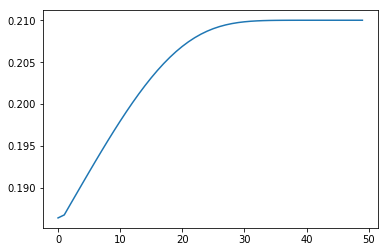

```python
    def plot(self):
        x = np.arange(NSTEP)
        plt.plot(x, self.X_Cr)
        #plt.plot(x, self.X_Fe, x, self.X_Cr, x, self.X_Ni)

    def main(self):
        """
        """
        self.empty_files()
        self.update_coefficients()
        self.solve()
        #self.solve_odeint()
        #print(self.X_Cr)
        #plt.plot(range(NSTEP), self.X_Cr[-1, :])


if __name__ == "__main__":
    ris = RIS()
    ris.main()
```

**Reference:**

A Tutorial for the Odespy Interface to ODE Solvers

http://hplgit.github.io/odespy/doc/pub/tutorial/html/main_odespy.html

Example codes

https://github.com/hplgit/odespy/blob/master/doc/src/tutorial/src-odespy/pde_diffusion.py